# Basic Experiment Design in Psychology and Cognitive Science

2024

## Experiment Design in Psychology and Cognitive Science

- This deck covers an essential element of experiment design in psychology and cognitive science: between-subjects vs. within-subjects designs, repeated measures, and mixed designs.

## Between-subjects vs. Within-subjects

- **Between-Subjects Design**:
  - Different participants are used for different conditions of the experiment.
  - Example: Comparing reaction times of two groups on two different tasks.
- **Within-Subjects Design**:
  - The same participants are used across all conditions of the experiment.
  - Example: Measuring memory recall in the same group of participants with and without a cue.

## Detecing Design From a `data.table`

- **Within-subejct design**

```
##    participant condition score
##          <num>    <char> <num>
## 1:           1         A    10
## 2:           1         B    12
## 3:           2         A    11
## 4:           2         B    13
## 5:           3         A     9
## 6:           3         B    11
```

- Notice the repeats in the `participant` column.

## Detecing Design From a `data.table`

- **Between-subject design**

```
##    participant condition score
##          <num>    <char> <num>
## 1:           1         A    10
## 2:           2         A    11
## 3:           3         A     9
## 4:           4         B    10
## 5:           5         B    11
## 6:           6         B     9
```

- Notice the lack of repeats in the `participant` column.

## Repeated Measures

- **Repeated Measures Design** involves multiple measurements from the same source.
- The *source* is usually a *participant* so a repeated measures design is usually – but not always – a within-subjects design.
- E.g., A repeated measures design that isn’t also a within-subject design is collecting multiple mesurement from the same EEG sensors over multiple days, but each day with a different participant.

## Mixed Designs

- **Mixed Designs** combine elements of both between-subjects and within-subjects designs.
- At least one variable is manipulated as a between-subjects factor, and another as a within-subjects factor.

## Mixed Design `data.table`

```
##    participant condition  group score
##          <num>    <char> <char> <num>
## 1:           1         A      X    10
## 2:           1         B      X    12
## 3:           2         A      Y    11
## 4:           2         B      Y    13
## 5:           3         A      Z     9
## 6:           3         B      Z    11
```

- Notice that the `group` column is a between-subjects factor, while the `condition` column is a within-subjects factor.

## Choosing Between Between-Subjects and Within-Subjects

- **Carryover Effects**:
  - Within-subjects designs suffer from carryover.
- **Statistical Power**:
  - Within-subjects designs have higher power.
- **Cost**:
  - Between-subjects designs can be more resource-intensive.
- **Generalizability**:
  - Between-subjects more generalizable.

## Example:

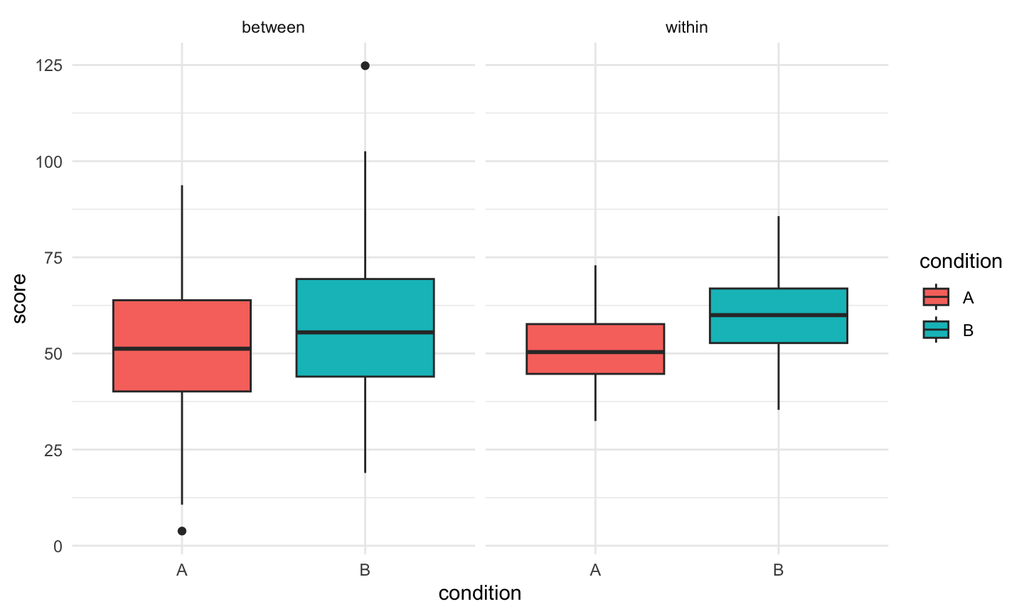

## Question 1:

Consider the following `data.table` output from an experiment:

```
   participant condition score
1:           1         A    12
2:           2         A    15
3:           3         A    13
4:           4         B    14
5:           5         B    16
6:           6         B    12
```

What type of experimental design does this data represent?

- Within-subjects design
- Between-subjects design
- Mixed design
- Repeated measures design

**Answer**

**Correct Answer:** B) Between-subjects design

## Question 2:

Review this `data.table` output:

```
   participant condition score
1:           1         A    10
2:           1         B    12
3:           2         A    11
4:           2         B    13
5:           3         A     9
6:           3         B    11
```

Which experimental design is illustrated by this `data.table`?

- Within-subjects design
- Between-subjects design
- Mixed design
- Repeated measures design

**Answer**

**Correct Answer:** A) Within-subjects design

## Question 3:

Given the `data.table` output from a study:

```
   participant condition group score
1:           1         A     X    10
2:           1         B     X    12
3:           2         A     Y    11
4:           2         B     Y    13
5:           3         A     Z     9
6:           3         B     Z    11
```

What type of design does this dataset suggest?

- Within-subjects design
- Between-subjects design
- Mixed design
- Repeated measures design

**Answer**

**Correct Answer:** C) Mixed design

## Question 4:

Examine the output below from a `data.table`:

```
   participant condition score
1:           1         A    14
2:           2         A    15
3:           1         B    16
4:           2         B    14
5:           3         A    13
6:           3         B    15
```

Based on this output, which experimental design is being used?

- Within-subjects design
- Between-subjects design
- Mixed design
- Repeated measures design

**Answer**

**Correct Answer:** A) Within-subjects design